# Forecasting!

Lucas

2025-10-17

Output dos modelos agregados processados com base no fechamento do dia 19/12, verificando tendências de médio prazo a partir do primeiro pregão subsequente para cada um dos mais de 300 ativos negociados na bolsa de valores. O gráfico a seguir mostra os ativos que apresentaram f1 score igual ou superior a 70%:

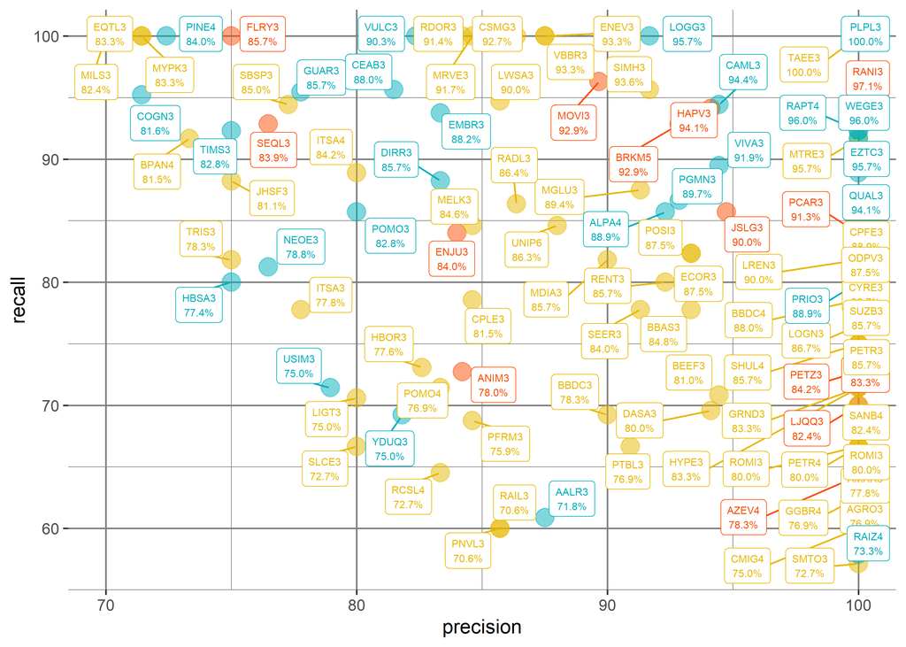

### Resultados

Nesta rodada de mineração, os ativos #AALR3, #ALPA4, #CAML3, #CEAB3, #COGN3, #DIRR3, #EMBR3, #EZTC3, #GUAR3, #HBSA3, #LOGG3, #NEOE3, #PGMN3, #PINE4, #PLPL3, #POMO3, #PRIO3, #QUAL3, #RAIZ4, #RAPT4, #TIMS3, #USIM3, #VIVA3, #VULC3, #WEGE3 e #YDUQ3 apresentaram comportamento característico de provável viés de elevação de alvo para swing trading.

Índices de precisão/recall/fscore/underp: #AALR3(87.50% 60.87% 71.8% 6.25% COMPRA), #ALPA4(92.31% 85.71% 88.9% 0.00% NEUTRO), #CAML3(94.44% 94.44% 94.4% 0.00% NEUTRO), #CEAB3(81.48% 95.65% 88.0% 0.00% COMPRA), #COGN3(71.43% 95.24% 81.6% 3.57% NEUTRO), #DIRR3(83.33% 88.24% 85.7% 0.00% COMPRA), #EMBR3(83.33% 93.75% 88.2% 0.00% NEUTRO), #EZTC3(100.00% 91.67% 95.7% 0.00% NEUTRO), #GUAR3(77.78% 95.45% 85.7% 0.00% COMPRA), #HBSA3(75.00% 80.00% 77.4% 0.00% NEUTRO), #LOGG3(91.67% 100.00% 95.7% 0.00% NEUTRO), #NEOE3(76.47% 81.25% 78.8% 0.00% VENDA), #PGMN3(92.86% 86.67% 89.7% 0.00% NEUTRO), #PINE4(72.41% 100.00% 84.0% 0.00% VENDA), #PLPL3(100.00% 100.00% 100.0% 0.00% NEUTRO), #POMO3(80.00% 85.71% 82.8% 0.00% NEUTRO), #PRIO3(100.00% 80.00% 88.9% 0.00% NEUTRO), #QUAL3(100.00% 88.89% 94.1% 0.00% NEUTRO), #RAIZ4(100.00% 57.89% 73.3% 0.00% VENDA), #RAPT4(100.00% 92.31% 96.0% 0.00% NEUTRO), #TIMS3(75.00% 92.31% 82.8% 0.00% NEUTRO), #USIM3(78.95% 71.43% 75.0% 0.00% VENDA), #VIVA3(94.44% 89.47% 91.9% 0.00% NEUTRO), #VULC3(82.35% 100.00% 90.3% 0.00% NEUTRO), #WEGE3(100.00% 92.31% 96.0% 0.00% VENDA) e #YDUQ3(81.82% 69.23% 75.0% 0.00% NEUTRO) respectivamente.

Segue representação gráfica dos ativos listados acima:

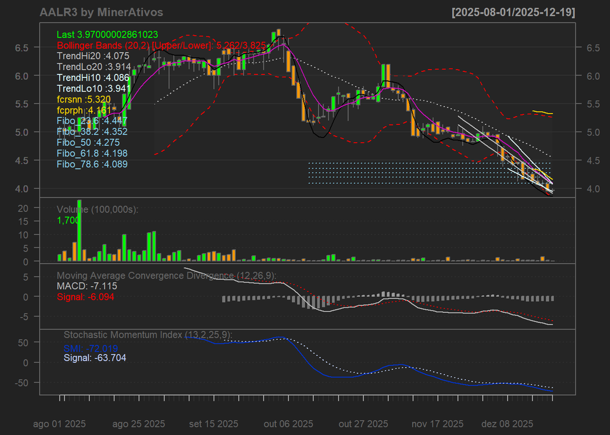

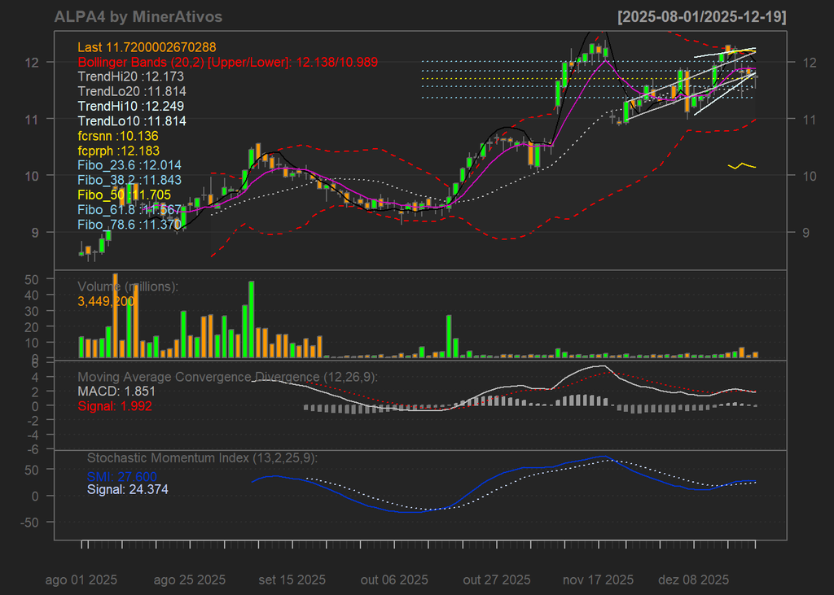

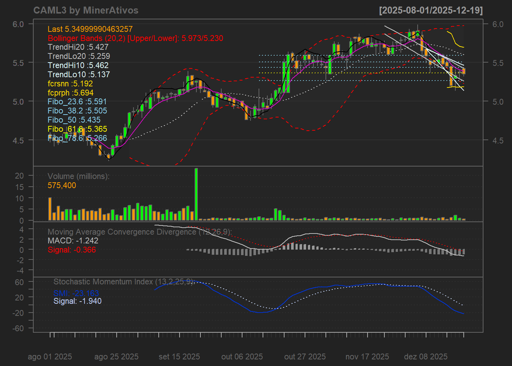

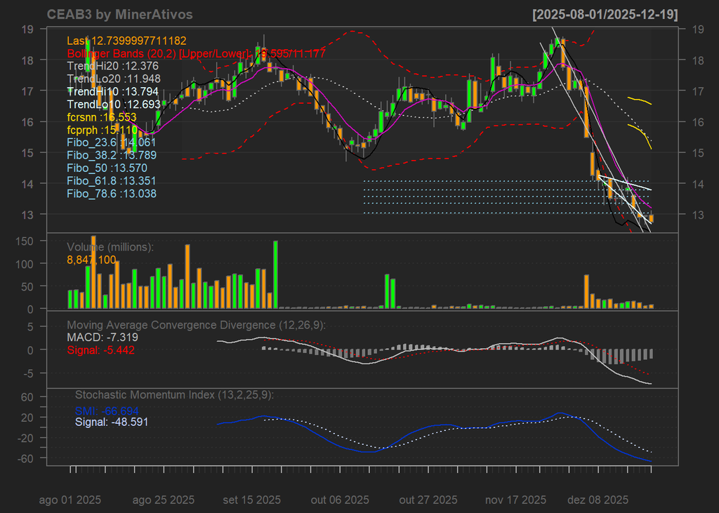

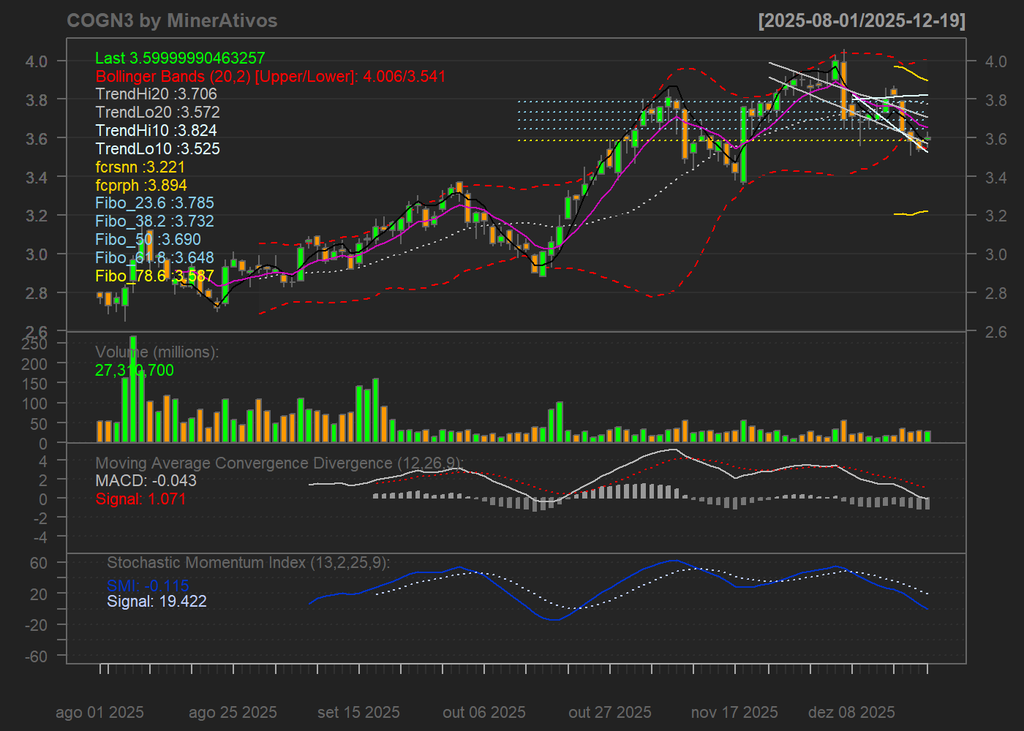

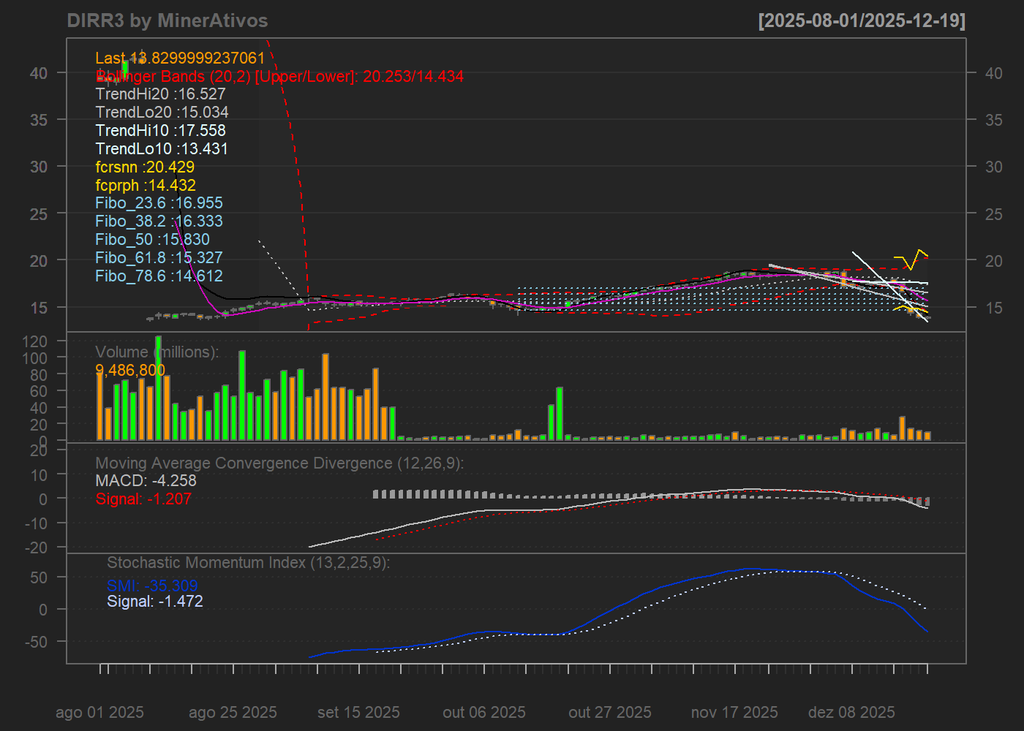

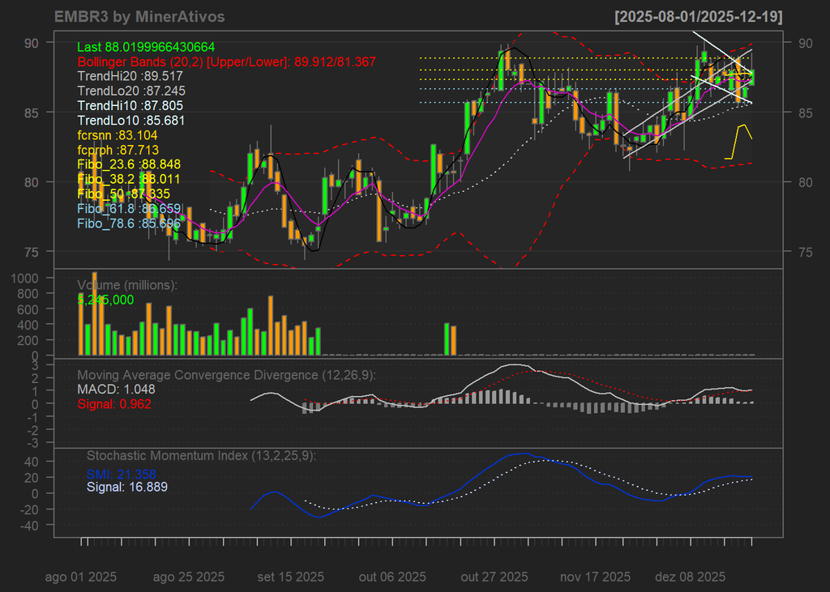

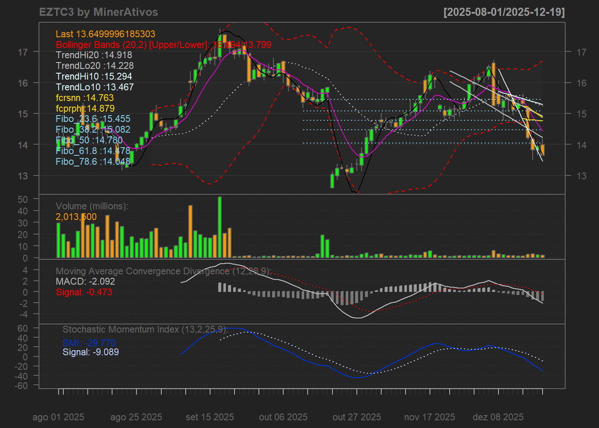

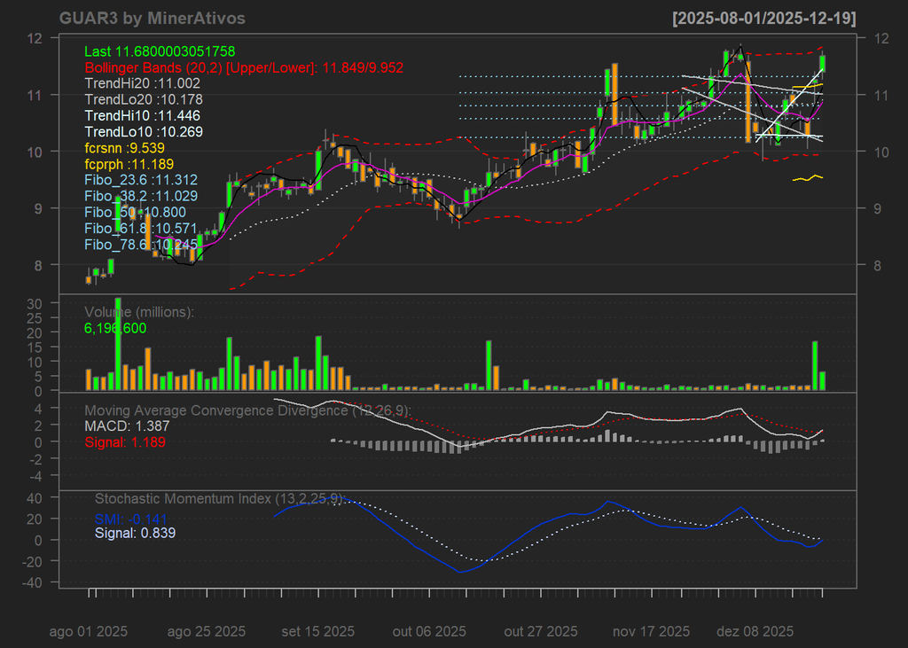

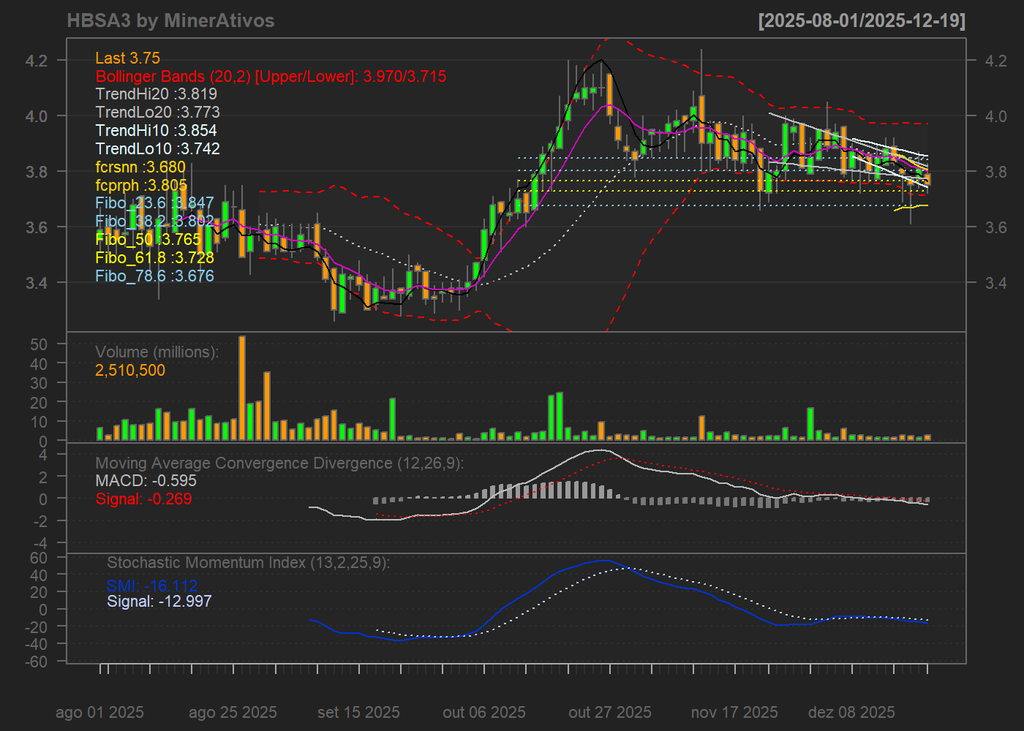

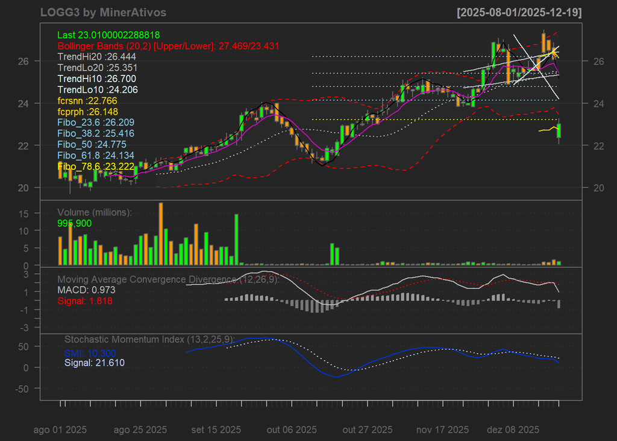

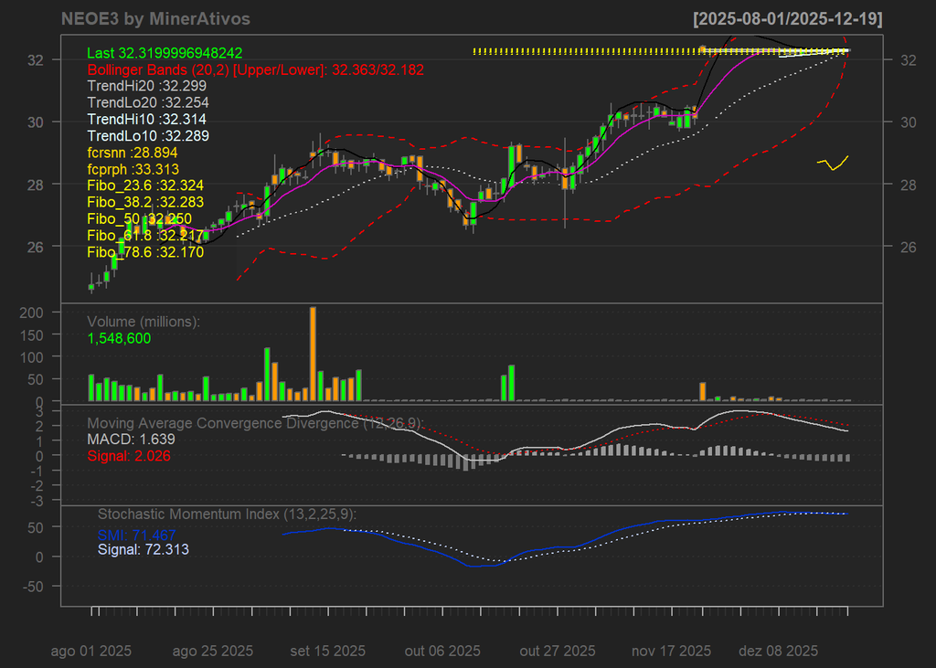

[14 more figures not shown]

#### **Acompanhe a visão intraday de #AALR3**

#### **Acompanhe a visão intraday de #ALPA4**

#### **Acompanhe a visão intraday de #CAML3**

#### **Acompanhe a visão intraday de #CEAB3**

#### **Acompanhe a visão intraday de #COGN3**

#### **Acompanhe a visão intraday de #DIRR3**

#### **Acompanhe a visão intraday de #EMBR3**

#### **Acompanhe a visão intraday de #EZTC3**

#### **Acompanhe a visão intraday de #GUAR3**

#### **Acompanhe a visão intraday de #HBSA3**

#### **Acompanhe a visão intraday de #LOGG3**

#### **Acompanhe a visão intraday de #NEOE3**

#### **Acompanhe a visão intraday de #PGMN3**

#### **Acompanhe a visão intraday de #PINE4**

#### **Acompanhe a visão intraday de #PLPL3**

#### **Acompanhe a visão intraday de #POMO3**

#### **Acompanhe a visão intraday de #PRIO3**

#### **Acompanhe a visão intraday de #QUAL3**

#### **Acompanhe a visão intraday de #RAIZ4**

#### **Acompanhe a visão intraday de #RAPT4**

#### **Acompanhe a visão intraday de #TIMS3**

#### **Acompanhe a visão intraday de #USIM3**

#### **Acompanhe a visão intraday de #VIVA3**

#### **Acompanhe a visão intraday de #VULC3**

#### **Acompanhe a visão intraday de #WEGE3**

#### **Acompanhe a visão intraday de #YDUQ3**

Os dados apresentados resultaram de algoritmos de aprendizado de máquina (ML) com base histórica e comportamental de cada ativo, além da apuração de indicadores técnicos e variáveis formadas a partir de informações endógenas e exógenas. Importante destacar que, além dessas informações, é necessário combinar com análises técnicas e fundamentalistas complementares. Mas isso não basta para o processo decisório, pois em alguns casos, ocorrem oscilações decorrentes de fatores e notícias relacionadas a empresas, política e economia, descolando as cotações dos modelos de forecast. Por isso, cautela e observação são fundamentais para todos os cenários, pois o mercado possui comportamento caótico, com volatilidade ampla e sensibilidade ao cenário político econômico.

Até a próxima!

*Exoneração de responsabilidade*[^1]

[^1]: Os dados apresentados são calculados somente para fins de ensaios estatísticos e de informação pessoal, e não de negociações ou recomendações sobre investimentos, tributos, questões jurídicas, financeiras ou outros assuntos. Consulte seu agente ou representante financeiro para verificar os preços antes de executar qualquer negociação. Este canal não se propõe ou tem qualquer intuito ou papel de um consultor de investimentos. Os dados e as informações não constituem uma recomendação para comprar, vender ou reter títulos ou produtos financeiros. Não fazemos declarações sobre a conveniência ou a adequação de qualquer investimento.